# Gyuwon Kwak_Natural Language Processing Project

#### TF-IDF Model의 Logistics Regression

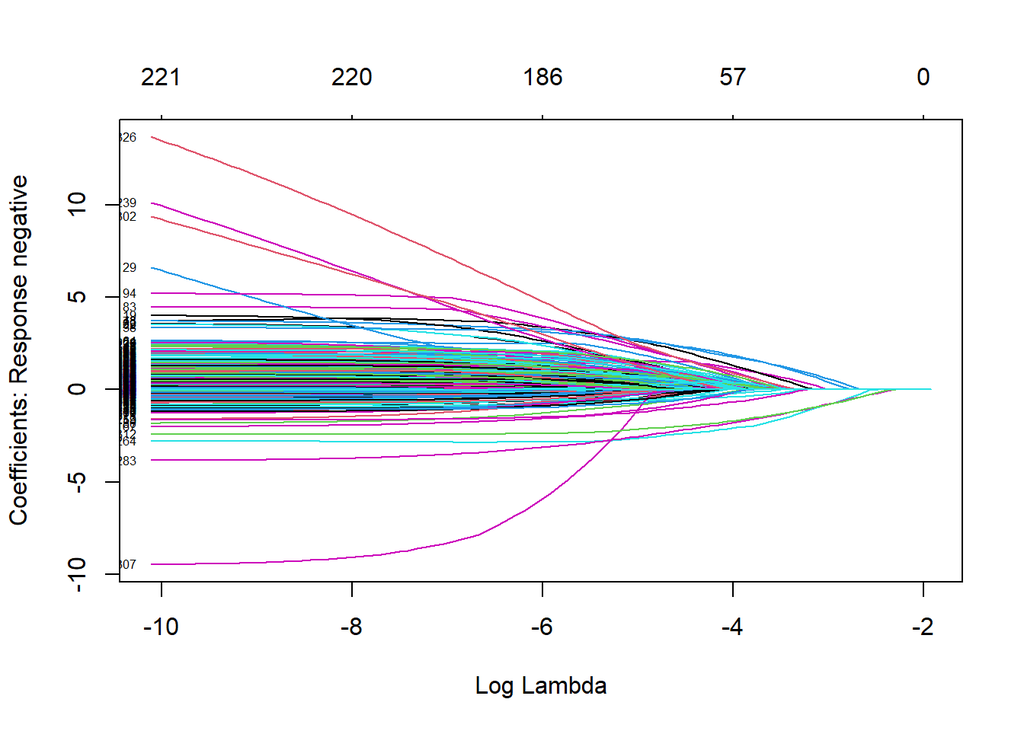

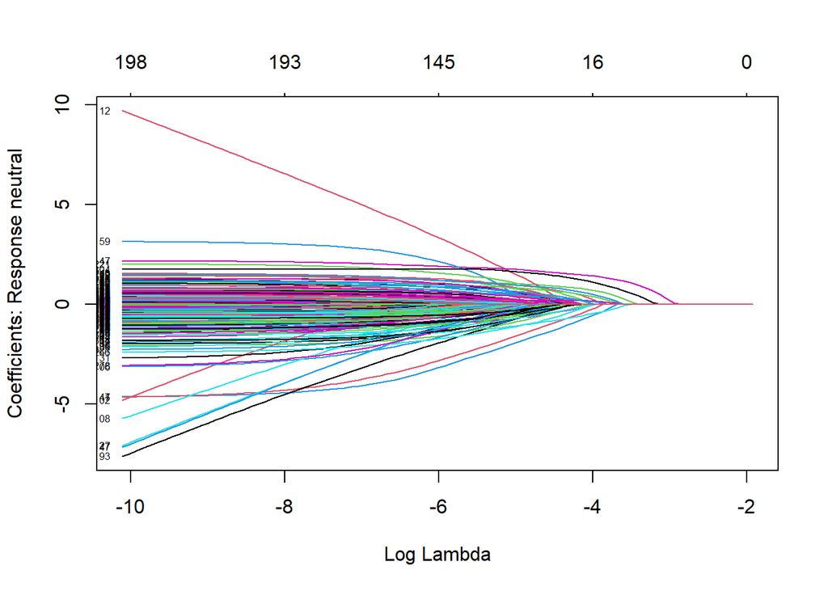

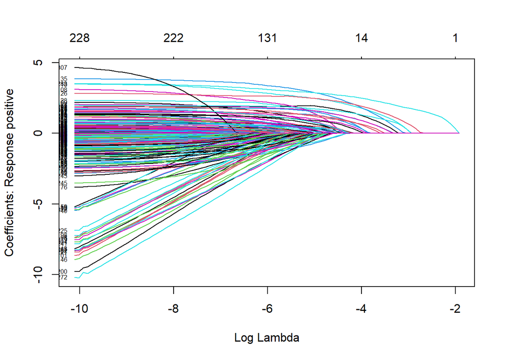

```r
# Backward stepwise Selection은 계산 시간이 너무 오래걸려 수행하지 못하였다.
# mlr_tfidf_step <- step(mlr_tfidf, direction="backward")

# Lasso Regression을 통해 Regularization을 진행한다.
# Feature Matrix 생성
trainX_tfidf <- model.matrix(sentiment~., data= tw_tfidf_trainf)[,-331]
trainY_tfidf <- tw_tfidf_trainf$sentiment

# Lasso Regression 수행
set.seed(100)
mlr_tfidf_las <- glmnet(x=trainX_tfidf, y= trainY_tfidf, alpha=1, family = "multinomial")
plot(mlr_tfidf_las, xvar="lambda", label=TRUE)
```

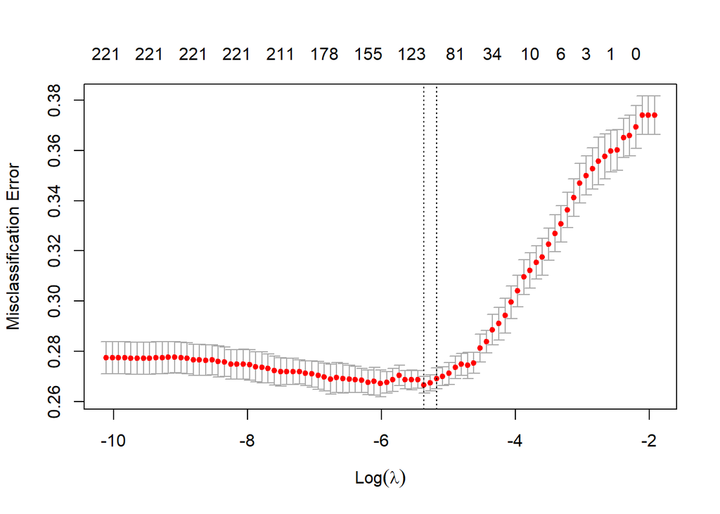

```r
# lambda 값에 대한 Cross calidation 수행
# multinomial Model에 대해서는 auc로 분석할 수 없다는 경고가 나와 Accuracy를 기준으로 수행하였다.
set.seed(100)
mlr_tfidf_las_cv <- cv.glmnet(x=trainX_tfidf, y= trainY_tfidf, alpha=1,
                              family = "multinomial", type.measure = "class", nfolds=5)

plot(mlr_tfidf_las_cv)
```

Miss classification Error가 계속 비교적 낮은 값을 보이다 갑자기 올라가는 구간은 Feature가 약 90개일 때였다.  
따라서 90~123개 정도의 변수를 가졌을 때 Error를 보고 변수의 수를 선택하도록 하자.

```r
#nonzero 변수의 수 출력
mlr_tfidf_las_cv$nzero
```

```
##  s0  s1  s2  s3  s4  s5  s6  s7  s8  s9 s10 s11 s12 s13 s14 s15 s16 s17 s18 s19
##   0   0   0   0   0   1   1   1   1   2   2   3   4   5   6   6   8   8   9  10
## s20 s21 s22 s23 s24 s25 s26 s27 s28 s29 s30 s31 s32 s33 s34 s35 s36 s37 s38 s39
##  10  12  14  16  20  23  34  42  52  59  66  75  81  90  95 101 105 112 118 123
## s40 s41 s42 s43 s44 s45 s46 s47 s48 s49 s50 s51 s52 s53 s54 s55 s56 s57 s58 s59
## 134 140 140 143 145 149 155 159 166 169 170 172 175 178 184 189 194 198 202 206
## s60 s61 s62 s63 s64 s65 s66 s67 s68 s69 s70 s71 s72 s73 s74 s75 s76 s77 s78 s79
## 211 214 215 217 218 219 220 221 221 221 221 221 221 221 221 221 221 221 221 221
## s80 s81 s82 s83 s84 s85 s86 s87 s88
## 221 221 221 221 221 221 221 221 221
```

```r
#miss classification Error 출력
mlr_tfidf_las_cv$cvm
```

```
##  [1] 0.3740 0.3740 0.3740 0.3694 0.3660 0.3650 0.3602 0.3598 0.3576 0.3558
## [11] 0.3528 0.3500 0.3470 0.3412 0.3364 0.3308 0.3270 0.3226 0.3176 0.3154
## [21] 0.3122 0.3096 0.3040 0.2996 0.2942 0.2910 0.2886 0.2838 0.2812 0.2754
## [31] 0.2744 0.2748 0.2736 0.2712 0.2700 0.2692 0.2674 0.2666 0.2688 0.2686
## [41] 0.2688 0.2704 0.2686 0.2676 0.2672 0.2680 0.2676 0.2684 0.2688 0.2690
## [51] 0.2692 0.2696 0.2690 0.2698 0.2704 0.2710 0.2712 0.2718 0.2720 0.2720
## [61] 0.2718 0.2724 0.2732 0.2736 0.2738 0.2746 0.2748 0.2748 0.2748 0.2758
## [71] 0.2760 0.2766 0.2764 0.2766 0.2766 0.2772 0.2774 0.2776 0.2776 0.2774
## [81] 0.2774 0.2772 0.2772 0.2772 0.2772 0.2774 0.2774 0.2774 0.2774
```

```r
# 변수의 개수가 118개일 때 lambda 값 저장
lambda_tfidf <- mlr_tfidf_las_cv$lambda[38]

# 어떤 Feature가 포함되었는지 출력은 보고서가 너무 길어지기 때문에 출력만 해보고 주석처리 하였다.
# coef(mlr_tfidf_las_cv, s= lambda_tfidf)


# Prediction을 위해 Test Dataset에 Target Feature를 포함시켜준다.
tw_tfidf_testf <- cbind(tw_tfidf_test, twt$airline_sentiment[5001:14640])
tw_dtm_testf <- cbind(tw_dtm_test, twt$airline_sentiment[5001:14640])
# Target 이름 바꿔주기
names(tw_tfidf_testf)[331] <- c("sentiment")
names(tw_dtm_testf)[331] <- c("sentiment")


# test set에 대해 예측
mlr_tfidf_pred <- predict(mlr_tfidf_las_cv, newx = model.matrix(sentiment~., data= tw_tfidf_testf)[,-331],
                          s= lambda_tfidf, type = "class")

# Confusion Matrix 출력
confusionMatrix(factor(mlr_tfidf_pred, levels = c("positive", "negative", "neutral")), tw_test)
```

```
## Confusion Matrix and Statistics
##
##           Reference
## Prediction negative neutral positive
##   negative     5595    1256      601
##   neutral       286     545       92
##   positive      167     241      857
##
## Overall Statistics
##
##                Accuracy : 0.7258
##                  95% CI : (0.7168, 0.7347)
##     No Information Rate : 0.6274
##     P-Value [Acc > NIR] : < 2.2e-16
##
##                   Kappa : 0.4211
##
##  Mcnemar's Test P-Value : < 2.2e-16
##
## Statistics by Class:
##
##                      Class: negative Class: neutral Class: positive
## Sensitivity                   0.9251        0.26690          0.5529
## Specificity                   0.4830        0.95025          0.9496
## Pos Pred Value                0.7508        0.59047          0.6775
## Neg Pred Value                0.7930        0.82827          0.9173
## Prevalence                    0.6274        0.21183          0.1608
## Detection Rate                0.5804        0.05654          0.0889
## Detection Prevalence          0.7730        0.09575          0.1312
## Balanced Accuracy             0.7041        0.60857          0.7512
```

TF-IDF Model은 Test set에 대하여 예측 결과 정확도 72.58%, 민감도는 각각 92.51%, 26.69%, 55.29%이고, 특이도는 48.30%, 95.03%, 94.96%이다.  
Negative한 평가에 대해서는 잘 분류하는 것으로 보이지만 Neutral한 평가(민감도 26.69%)와 positive한 평가(민감도 55.29%)에 대해서는 잘 예측하지 못한 것을 알 수 있다.

#### DTM Model의 Logistics Regression

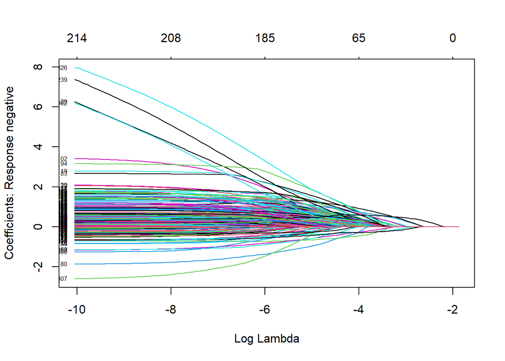

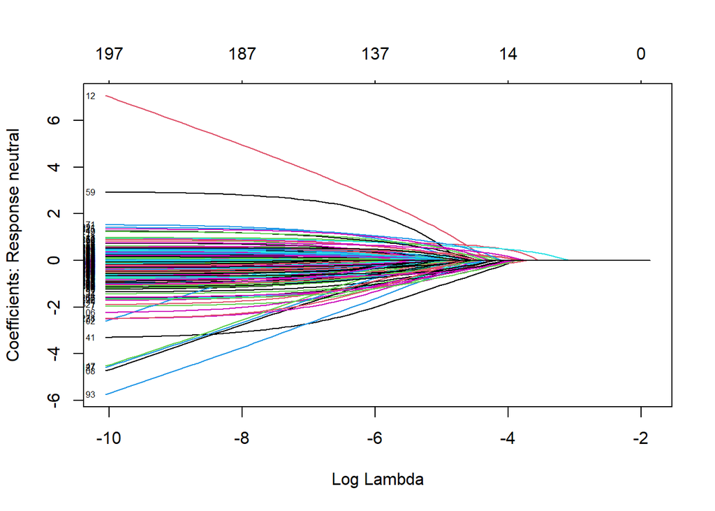

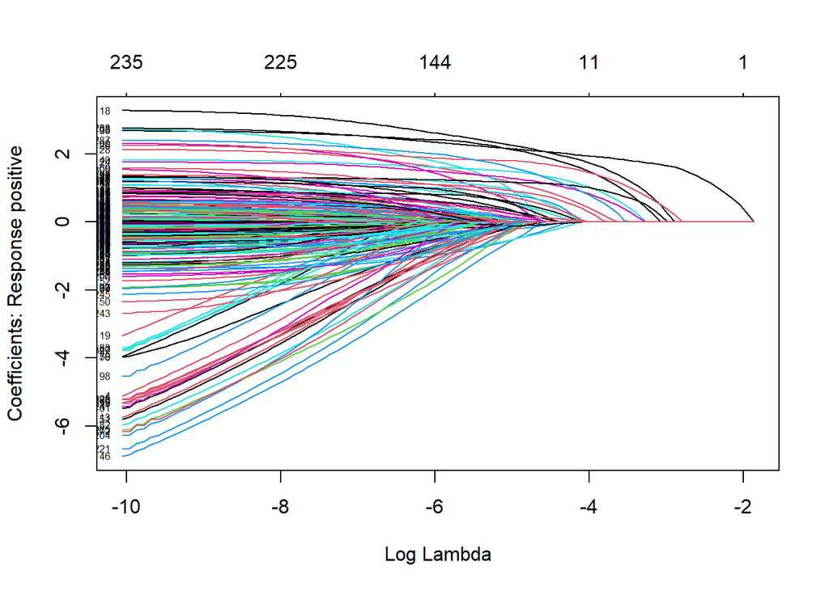

```r
# Lasso Regression을 통해 Regularization을 진행한다.
# Feature Matrix 생성
trainX_dtm <- model.matrix(sentiment~., data= tw_dtm_trainf)[,-331]
trainY_dtm <- tw_dtm_trainf$sentiment

# Lasso Regression 수행
set.seed(100)
mlr_dtm_las <- glmnet(x=trainX_dtm, y= trainY_dtm, alpha=1, family = "multinomial")
plot(mlr_dtm_las, xvar="lambda", label=TRUE)
```

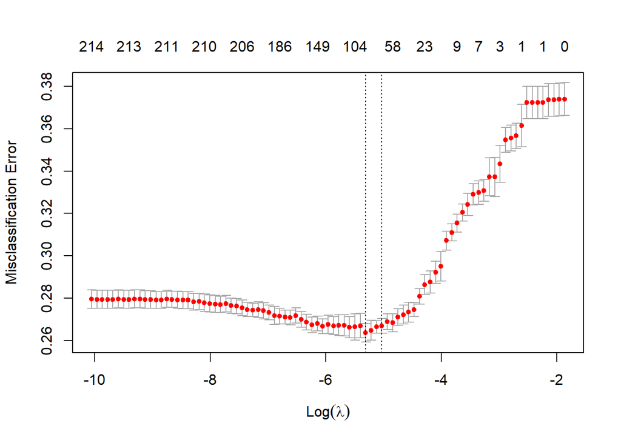

```r
# lambda 값에 대한 Cross calidation 수행
set.seed(100)
mlr_dtm_las_cv <- cv.glmnet(x=trainX_dtm, y= trainY_dtm, alpha=1,
                              family = "multinomial", type.measure = "class", nfolds=5)

plot(mlr_dtm_las_cv)
```

Miss classification Error가 계속 비교적 낮은 값을 보이다 갑자기 올라가는 구간은 Feature가 약 70개일 때였다.  
따라서 70~104개 정도의 변수를 가졌을 때 Error를 보고 변수의 수를 선택하도록 하자.

```r
#nonzero 변수의 수 출력
mlr_dtm_las_cv$nzero
```

```
##  s0  s1  s2  s3  s4  s5  s6  s7  s8  s9 s10 s11 s12 s13 s14 s15 s16 s17 s18 s19
##   0   0   0   0   1   1   1   1   1   1   1   2   3   5   5   5   7   7   8   8
## s20 s21 s22 s23 s24 s25 s26 s27 s28 s29 s30 s31 s32 s33 s34 s35 s36 s37 s38 s39
##   9  10  10  14  16  20  23  26  34  41  47  52  58  70  78  82  89  94  98 104
## s40 s41 s42 s43 s44 s45 s46 s47 s48 s49 s50 s51 s52 s53 s54 s55 s56 s57 s58 s59
## 111 117 126 133 136 144 149 153 157 166 169 175 183 186 188 195 195 199 200 203
## s60 s61 s62 s63 s64 s65 s66 s67 s68 s69 s70 s71 s72 s73 s74 s75 s76 s77 s78 s79
## 206 206 207 208 207 206 208 210 211 211 211 210 210 210 211 211 211 211 211 211
## s80 s81 s82 s83 s84 s85 s86 s87 s88
## 213 213 213 213 213 213 213 213 214
```

```r
#miss classification Error 출력
mlr_dtm_las_cv$cvm
```

```
##  [1] 0.3740 0.3738 0.3736 0.3736 0.3724 0.3724 0.3724 0.3724 0.3614 0.3566
## [11] 0.3556 0.3548 0.3434 0.3372 0.3372 0.3308 0.3298 0.3290 0.3242 0.3204
## [21] 0.3154 0.3110 0.3072 0.2950 0.2922 0.2876 0.2864 0.2808 0.2746 0.2734
## [31] 0.2722 0.2710 0.2684 0.2688 0.2670 0.2664 0.2648 0.2636 0.2670 0.2664
## [41] 0.2662 0.2672 0.2672 0.2670 0.2676 0.2666 0.2680 0.2674 0.2686 0.2700
## [51] 0.2718 0.2708 0.2710 0.2714 0.2718 0.2732 0.2740 0.2746 0.2744 0.2746
## [61] 0.2754 0.2762 0.2764 0.2774 0.2770 0.2772 0.2774 0.2778 0.2784 0.2782
## [71] 0.2790 0.2790 0.2792 0.2794 0.2796 0.2792 0.2792 0.2794 0.2794 0.2796
## [81] 0.2796 0.2794 0.2794 0.2796 0.2794 0.2794 0.2794 0.2794 0.2796
```

```r
# 변수의 개수가 104개일 때 lambda 값 저장
lambda_dtm <- mlr_dtm_las_cv$lambda[39]

# 어떤 Feature가 포함되었는지 출력은 보고서가 너무 길어지기 때문에 출력만 해보고 주석처리 하였다.
# coef(mlr_dtm_las_cv, s= lambda_dtm)

# test set에 대해 예측
mlr_dtm_pred <- predict(mlr_dtm_las_cv, newx = model.matrix(sentiment~., data= tw_dtm_testf)[,-331],
                          s= lambda_dtm, type = "class")

# Confusion Matrix 출력
confusionMatrix(factor(mlr_dtm_pred, levels = c("positive", "negative", "neutral")), tw_test)
```

```
## Confusion Matrix and Statistics
##
##           Reference
## Prediction negative neutral positive
##   negative     4741     651      355
##   neutral      1009    1110      216
##   positive      298     281      979
##
## Overall Statistics
##
##                Accuracy : 0.7085
##                  95% CI : (0.6993, 0.7176)
##     No Information Rate : 0.6274
##     P-Value [Acc > NIR] : < 2.2e-16
##
##                   Kappa : 0.4687
##
##  Mcnemar's Test P-Value : < 2.2e-16
##
## Statistics by Class:
##
##                      Class: negative Class: neutral Class: positive
## Sensitivity                   0.7839         0.5436          0.6316
## Specificity                   0.7199         0.8388          0.9284
## Pos Pred Value                0.8250         0.4754          0.6284
## Neg Pred Value                0.6643         0.8724          0.9293
## Prevalence                    0.6274         0.2118          0.1608
## Detection Rate                0.4918         0.1151          0.1016
## Detection Prevalence          0.5962         0.2422          0.1616
## Balanced Accuracy             0.7519         0.6912          0.7800
```

DTM Model은 Test set에 대하여 예측 결과 정확도 70.85%, 민감도는 각각 78.39%, 54.36%, 63.16%이고, 특이도는 71.99%, 83.88%, 92.84%이다.  
Negative한 평가에 대해서는 적당히 분류하며(민감도 78.39%) Neutral한 평가(민감도 54.36%)는 여전히 잘 분류하지 못하고 있다.  
특정한 Feature가 아니라고 예측하는 정도의 비율인 특이도는 전체적으로 높게 나타났다.

**Logistic Regression 분석 결과 정리**

|  | 정확도 | 민감도 | 특이도 |
| --- | --- | --- | --- |
| TF-IDF 모델 | 0.7258 | 0.9251 / 0.26690 / 0.5529 | 0.4830 / 0.95025 / 0.9496 |
| DTM 모델 | 0.7085 | 0.7839 / 0.5436 / 0.6316 | 0.7199 / 0.8388 / 0.9284 |

정확도 측면에서는 TF-IDF 모델이 72.58%로 DTM 모델보다 약 2% 높은 것으로 나타났다.  
하지만 Netural한 평가를 Neutral이라고(민감도 측면) 예측하는 측면과 Negative가 아닌 것을 Negative가 아니라고(특이도 측면) 예측하는 측면에서는 TF-IDF 모델이 DTM보다 성능이 훨씬 떨어졌다.  
따라서 정확도가 약간 떨어지더라도 전체적으로 보았을 떄 DTM 모델을 선택하는 것도 괜찮아 보인다.

ROC Curve를 이용하여 두 모델의 성능을 비교하고자 하였으나 Multinomial일 때는 ROC Curve를 그릴 수 없다는 경고가 나와 그릴 수 없었다.  
나왔던 경고: Error in prediction(mlr_tfidf_prob, tw_test) : Number of classes is not equal to 2. ROCR currently supports only evaluation of binary classification tasks.

#### Classification Tree Model

Tree 모델은 그냥 만들면 Training Data에 Overfitting되기 때문에 Variance가 매우 높게 나타나는 경향이 있다.  
정확도가 높은 Model을 만들기 위해 많은 Tree를 생성하여 평균을 이용하는 Bagging 기법과 Tree의 Node를 분할할 때 랜덤으로 Feature를 선택하게 해주는 Random Forest을 적용해줄 것이다.  
보통의 경우 Bagging만 적용하는 것보다 Random Forest를 적용하는 것이 OOB MSE가 더 낮다는 것을 배웠음으로, 굳이 두 모델의 OOB MSE 값을 비교하거나 그러진 않겠다.

#### TF-IDF Model의 Classification Tree

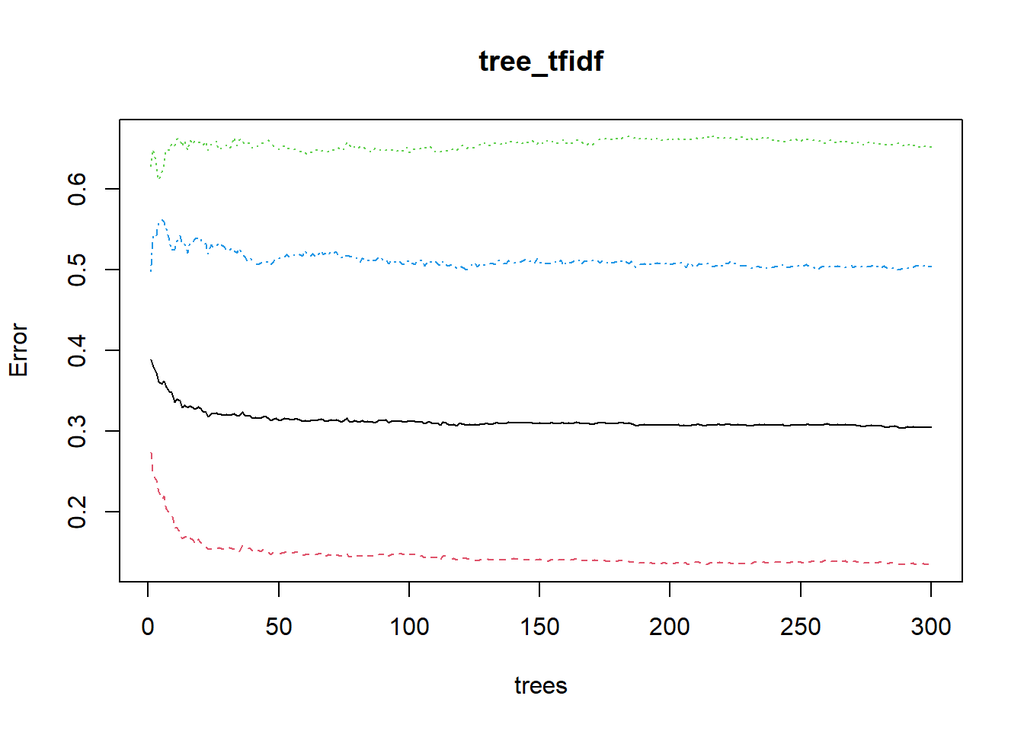

```r
# Traning set에 Bagging 및 Random Forest를 적용하기.
# mtry = floor(p/3) 으로 넣으면 Random Forest를 적용하는 것과 같다.
set.seed(100)
tree_tfidf <- randomForest(sentiment~., data = tw_tfidf_trainf, ntree=300, mtry = 110)

# Tree의 개수에 따른 out of bag MSE 시각화
plot(tree_tfidf)
```

for문을 이용하여 mtry값을 바꿔주며 OOB Error를 최소화하는 mtry의 값을 찾을 수 있지만, 계산이 너무 오래걸려 수행하지 못하였다. 따라서 Random Forest만 적용해주도록 하자.  
Tree가 약 10개정도 일 때 까지는 OOB Error가 급격히 감소하다가 그 이후에는 완만하게 감소하였다.

```r
# TF-IDF 모델에 대한 Test set에 대해 Class 예측
tree_tfidf_pred <- predict(tree_tfidf, newdata = tw_tfidf_testf, type="class")

# Confusion Matrix 출력
confusionMatrix(tree_tfidf_pred, tw_test)
```

```
## Confusion Matrix and Statistics
##
##           Reference
## Prediction negative neutral positive
##   negative     3939     583      218
##   neutral      1603    1200      329
##   positive      506     259     1003
##
## Overall Statistics
##
##                Accuracy : 0.6371
##                  95% CI : (0.6274, 0.6467)
##     No Information Rate : 0.6274
##     P-Value [Acc > NIR] : 0.02429
##
##                   Kappa : 0.3883
##
##  Mcnemar's Test P-Value : < 2e-16
##
## Statistics by Class:
##
##                      Class: negative Class: neutral Class: positive
## Sensitivity                   0.6513         0.5877          0.6471
## Specificity                   0.7770         0.7457          0.9054
## Pos Pred Value                0.8310         0.3831          0.5673
## Neg Pred Value                0.5696         0.8706          0.9305
## Prevalence                    0.6274         0.2118          0.1608
## Detection Rate                0.4086         0.1245          0.1040
## Detection Prevalence          0.4917         0.3249          0.1834
## Balanced Accuracy             0.7141         0.6667          0.7763
```

TF-IDF에 대한 Random Forest Model의 결과는 정확도 63.71%, 민감도는 각각 65.13%, 58.77$, 64.71%였으며, 특이도는 77.70%, 74.57%, 90.54%였다.  
정확도가 높지 않았으며, 민감도나 특이도도 그렇게 좋은 모델은 아니었다. Postive가 아닌 것만 아니라고 잘 분류하였다.

#### DTM Model의 Classification Tree

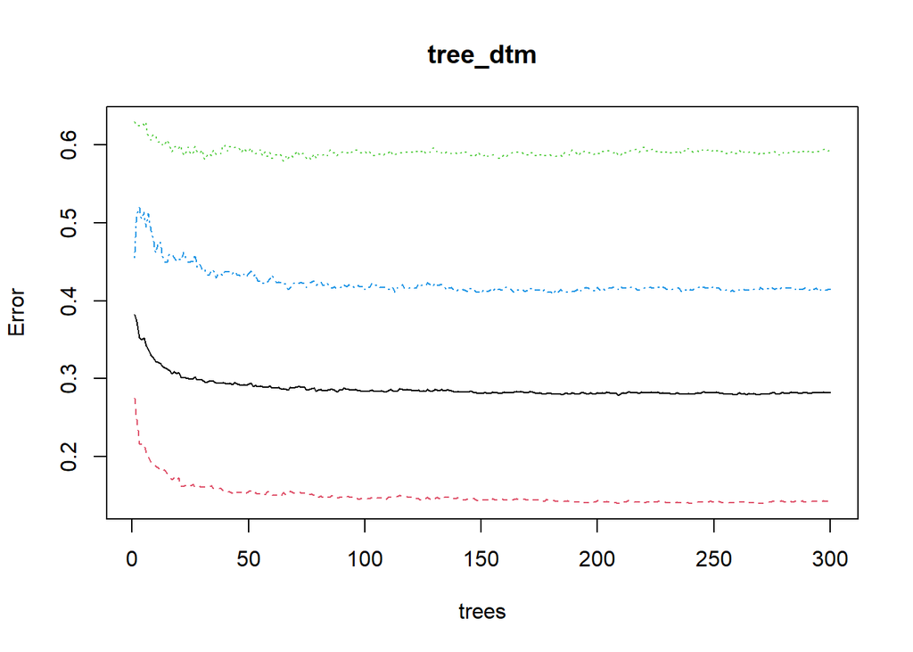

```r
# Traning set에 Bagging 및 Random Forest를 적용하기.
set.seed(100)
tree_dtm <- randomForest(sentiment~., data = tw_dtm_trainf, ntree=300, mtry = 110)

# Tree의 개수에 따른 out of bag MSE 시각화
plot(tree_dtm)
```

Tree가 약 25개정도 일 때 까지는 OOB Error가 급격히 감소하다가 그 이후에는 완만하게 감소하였다.

```r
# DTM 모델에 대한 Test set에 대해 Class 예측
tree_dtm_pred <- predict(tree_dtm, newdata = tw_dtm_testf, type="class")

# Confusion Matrix 출력
confusionMatrix(tree_dtm_pred, tw_test)
```

```
## Confusion Matrix and Statistics
##
##           Reference
## Prediction negative neutral positive
##   negative     4353     564      256
##   neutral      1231    1222      288
##   positive      464     256     1006
##
## Overall Statistics
##
##                Accuracy : 0.6827
##                  95% CI : (0.6733, 0.692)
##     No Information Rate : 0.6274
##     P-Value [Acc > NIR] : < 2.2e-16
##
##                   Kappa : 0.4475
##
##  Mcnemar's Test P-Value : < 2.2e-16
##
## Statistics by Class:
##
##                      Class: negative Class: neutral Class: positive
## Sensitivity                   0.7197         0.5984          0.6490
## Specificity                   0.7717         0.8001          0.9110
## Pos Pred Value                0.8415         0.4458          0.5829
## Neg Pred Value                0.6206         0.8811          0.9313
## Prevalence                    0.6274         0.2118          0.1608
## Detection Rate                0.4516         0.1268          0.1044
## Detection Prevalence          0.5366         0.2843          0.1790
## Balanced Accuracy             0.7457         0.6993          0.7800
```

**Tree(Random Forest) Model 분석 결과 정리**

[output not shown]

#### TF-IDF Model의 RBF Kernel SVM Model

```r
# RBF Kernel 사용시 gamma와 cost 두 파라미터에 대해 tuning을 하려 하였으나, ranges 값을 줄여도 계산 시간이 너무 오래 걸려 수행하지 못 하였다. 직접 바꿔가며 하기에도 SVM 함수의 실행해도 시간이 너무 오래 걸렸다.
# gamma와 cost를 1로 설정하여 RBF Kernel에 fitting 하였다.
svm_tfidf <- svm(sentiment~.,data = tw_tfidf_trainf, kernel = "radial",
                 gamma = 1, cost = 1)
# SVM 결과 살펴보기.
summary(svm_tfidf)
```

```
##
## Call:
## svm(formula = sentiment ~ ., data = tw_tfidf_trainf, kernel = "radial",
##     gamma = 1, cost = 1)
##
##
## Parameters:
##    SVM-Type:  C-classification
##  SVM-Kernel:  radial
##        cost:  1
##
## Number of Support Vectors:  4238
##
##  ( 1026 759 2453 )
##
##
## Number of Classes:  3
##
## Levels:
##  negative neutral positive
```

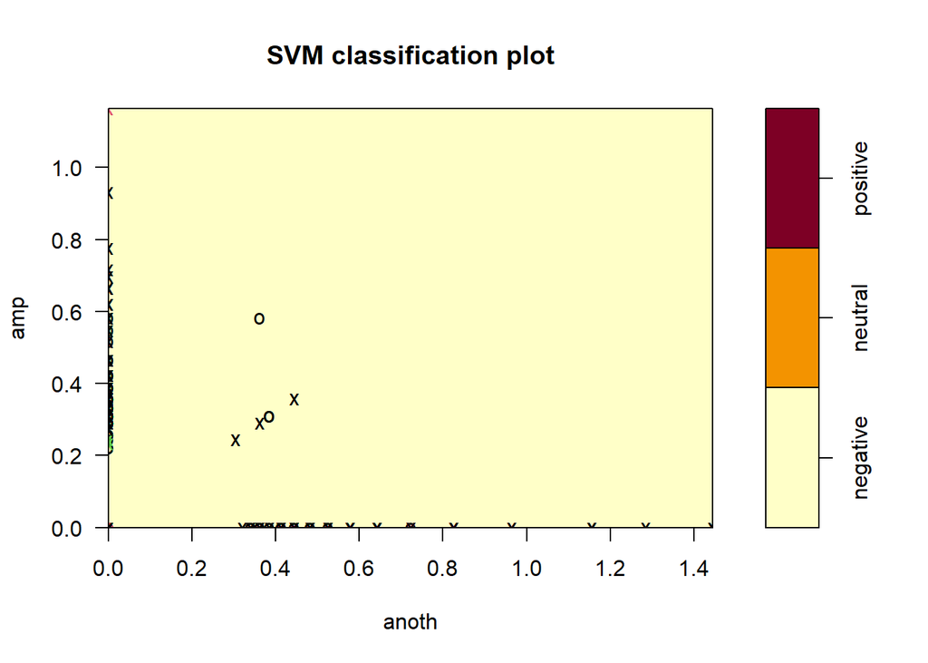

```r
# Tuning 결과 시각화해보기 한 번에 2개 까지만 나타낼 수 있다.
plot(svm_tfidf, data = tw_tfidf_trainf, amp~anoth)
```

```r
# Test set에 적용해보기
svm_tfidf_pred <- predict(svm_tfidf, newdata = tw_tfidf_testf)

# confusion Matrix 출력
confusionMatrix(svm_tfidf_pred, tw_test)
```

```
## Confusion Matrix and Statistics
##
##           Reference
## Prediction negative neutral positive
##   negative     5896    1693     1016
##   neutral       102     276       56
##   positive       50      73      478
##
## Overall Statistics
##
##                Accuracy : 0.6898
##                  95% CI : (0.6805, 0.6991)
##     No Information Rate : 0.6274
##     P-Value [Acc > NIR] : < 2.2e-16
##
##                   Kappa : 0.2622
##
##  Mcnemar's Test P-Value : < 2.2e-16
##
## Statistics by Class:
##
##                      Class: negative Class: neutral Class: positive
## Sensitivity                   0.9749        0.13516         0.30839
## Specificity                   0.2458        0.97921         0.98480
## Pos Pred Value                0.6852        0.63594         0.79534
## Neg Pred Value                0.8531        0.80817         0.88140
## Prevalence                    0.6274        0.21183         0.16079
## Detection Rate                0.6116        0.02863         0.04959
## Detection Prevalence          0.8926        0.04502         0.06234
## Balanced Accuracy             0.6103        0.55718         0.64659
```

TF-IDF에 대한 RBF Kernel SVM의 결과는 정확도 68.98%, 민감도는 각각 97.49%, 13.51%, 30.83%였으며, 특이도는 24.58%, 97.92%, 98.48%였다.  
정확도가 그리 높지 않았으며, Neutral과 positive인 것을 Neutral과 positive하다고 예측한 것(민감도)과 negative가 아닌 것을 negitive가 아니라고 예측한 것(특이도)에서 형편 없었다.  
하지만 그 반대는 극적으로 잘 분류하는 것을 볼 수 있었다.

#### DTM Model의 RBF Kernel SVM Model

```r
# gamma와 cost를 1로 설정하여 RBF Kernel에 fitting 하였다.
svm_dtm <- svm(sentiment~.,data = tw_dtm_trainf, kernel = "radial",
                 gamma = 1, cost = 1)
# SVM 결과 살펴보기.
summary(svm_dtm)
```

```
##
## Call:
## svm(formula = sentiment ~ ., data = tw_dtm_trainf, kernel = "radial",
##     gamma = 1, cost = 1)
##
##
## Parameters:
##    SVM-Type:  C-classification
##  SVM-Kernel:  radial
##        cost:  1
##
## Number of Support Vectors:  4857
##
##  ( 1000 760 3097 )
##
##
## Number of Classes:  3
##
## Levels:
##  negative neutral positive
```

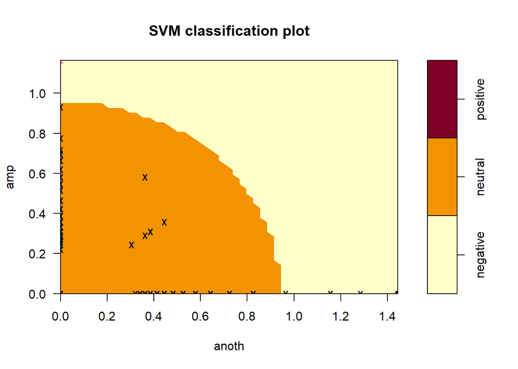

```r
# Tuning 결과 시각화해보기 한 번에 2개 까지만 나타낼 수 있다.
plot(svm_dtm, data = tw_tfidf_trainf, amp~anoth)
```

```r
# Test set에 적용해보기
svm_dtm_pred <- predict(svm_dtm, newdata = tw_dtm_testf)

# confusion Matrix 출력
confusionMatrix(svm_dtm_pred, tw_test)
```

```
## Confusion Matrix and Statistics
##
##           Reference
## Prediction negative neutral positive
##   negative     5942    1821     1343
##   neutral       105     198       59
##   positive        1      23      148
##
## Overall Statistics
##
##                Accuracy : 0.6523
##                  95% CI : (0.6427, 0.6618)
##     No Information Rate : 0.6274
##     P-Value [Acc > NIR] : 2.007e-07
##
##                   Kappa : 0.1231
##
##  Mcnemar's Test P-Value : < 2.2e-16
##
## Statistics by Class:
##
##                      Class: negative Class: neutral Class: positive
## Sensitivity                   0.9825        0.09696         0.09548
## Specificity                   0.1192        0.97842         0.99703
## Pos Pred Value                0.6525        0.54696         0.86047
## Neg Pred Value                0.8015        0.80125         0.85192
## Prevalence                    0.6274        0.21183         0.16079
## Detection Rate                0.6164        0.02054         0.01535
## Detection Prevalence          0.9446        0.03755         0.01784
## Balanced Accuracy             0.5508        0.53769         0.54626
```

DTM에 대한 RBF Kernel SVM의 결과는 정확도 65.23%, 민감도는 각각 98.25%, 9.69%, 9.54%였으며, 특이도는 11.92%, 97.84%, 99.70%였다.  
DTM 모델도 TF-IDF 모델과 같이 Neutral과 positive인 것을 Neutral과 positive하다고 예측한 것(민감도)과 negative가 아닌 것을 negitive가 아니라고 예측한 것(특이도)에서 형편 없었다.  
하지만 그 반대는 극적으로 잘 분류하는 것을 볼 수 있었다.

**SVM RBF Kernel Model 분석 결과 정리**

|  | 정확도 | 민감도 | 특이도 |
| --- | --- | --- | --- |
| TF-IDF 모델 | 0.6898 | 0.9749 / 0.13516 / 0.30839 | 0.2458 / 0.97921 / 0.98480 |
| DTM 모델 | 0.6523 | 0.9825 / 0.09696 / 0.09548 | 0.1192 / 0.97842 / 0.99703 |

정확도는 TF-IDF 모델이 68.98%로 정확도가 65.23%인 DTM 모델에 비해 약 4% 높았다.  
하지만 두 모델 모두 Neutral과 positive인 것을 Neutral과 positive하다고 예측한 것(민감도)과 negative가 아닌 것을 negitive가 아니라고 예측한 것에 대해서는 형편없는 성능을 보여주었고, negative인 것을 negative 하다고 예측한 것과 netural이 아닌 것과 positive가 아닌 것을 각각 아니라고 예측한 것에 대해서는 매우 높은 성능을 보였다.  
정확도가 매우 높지도 않고 무엇보다, 앞서 말한 특성 때문에 실 예측에 쓰기에 적합해 보이진 않는다.  
**다만 기술적 문제로 Parameter Tuning을 수행하지 않았음에도 불구하고 정확도가 나쁘지 않았다. Parameter Tuning을 수행한 모델로 했다면 높은 정확도가 나왔을 가능성도 충분해보인다.**

#### B. 최종 모델 선택하기

**전체 Model 들에 대한 Accracy 정리**

[output not shown]

전체적으로 정확도가 높은 Logistic Regression Model 중에서도 TF-IDF 값을 기준으로 만든 Model이 가장 높은 정확도를 보였다.

**Logistic Regression 분석 결과 정리**

|  | 정확도 | 민감도 | 특이도 |
| --- | --- | --- | --- |
| TF-IDF 모델 | 0.7258 | 0.9251 / 0.26690 / 0.5529 | 0.4830 / 0.95025 / 0.9496 |
| DTM 모델 | 0.7085 | 0.7839 / 0.5436 / 0.6316 | 0.7199 / 0.8388 / 0.9284 |

하지만 앞서 말했듯이 민감도와 특이도 측면에서 보았을 때는 TF-IDF 모델이 DTM보다 성능이 훨씬 떨어졌다.  
정확도는 2%밖에 차이나지 않으므로, **Logistic Regression Model의 DTM Model을 최종 선택한다.**

#### C. 어떤 class를 분류하기 어려운가?

앞서 분석한 모든 모델에 대해 민감도와 특이도를 정리해보았다. 분류하기 어려운 것을 찾기 위해 민감도를 집중적으로 분석해보자.

**Summary of Sensitivity**

[output not shown]

각 모델들의 민감도를 살펴보았을 때 평균이 제일 낮은 Class는 Positive 였고, 약 2%차이로 Neutral도 비슷하게 낮게 나타났다.  
따라서 Neutral과 Positive한 트윗(텍스트)들을 실제로 맞게 예측을 잘 하지 못하였다.

**Summary of Specificity**

[output not shown]

각 모델들의 특이도를 살펴보았을 때 평균이 제일 낮은 Class는 Negative였다.  
따라서 Negative가 아닌 것을 Negative가 아니라고 예측하는 성능이 제일 낮았지만, 59.15%정도로 앞서 살펴본 민감도에 비하면 비교적 높은 편이었다.  
**민감도와 특이도를 종합적으로 살펴보았을 때 Neutral한 Class제일 분류하기 힘들었다고 할 수 있다.**

-끝-